# Activity 1 — Task 5: Binary Logistic Regression Modeling

Group 08

This task analyzes which professional and employer characteristics are associated with being in the highest-paid salary tier. The response variable is a binary indicator based on the sample 75th percentile of `salary_in_usd`. Unlike the continuous models in Task 4, the fitted values here are probabilities, so binary logistic regression is appropriate.

The supplied training and test datasets contain 565 cleaned observations with no missing values or duplicates. The predictors are grouped or converted to factors where needed so that sparse categories do not create unstable estimates.

```r
library(tidyverse)
train <- read.csv("dataset/train_data.csv")
test <- read.csv("dataset/test_data.csv")
data <- bind_rows(train, test)
```

# 5 Binary Logistic Regression Modeling

This analysis follows a clear workflow: define the binary target, prepare predictors and fit the logistic model, interpret the model and its fit, evaluate in-sample classification, generate out-of-sample predictions, and summarize the main findings.

## 5.1 Binary target: `is_top_tier` (Q3 = 75th percentile)

The cut-off is the sample 75th percentile of `salary_in_usd`. A professional is classified as top-tier when their salary is at least this cut-off. The use of `>=` follows the project definition; consequently, observations tied exactly at the cut-off are all retained in the top-tier class.

```r
q3_salary <- as.numeric(quantile(data$salary_in_usd, probs = 0.75, na.rm = TRUE))

data <- data %>%
  mutate(
    row_id = row_number(),
    is_top_tier = if_else(salary_in_usd >= q3_salary, 1L, 0L)
  )

train <- train %>%
  mutate(is_top_tier = if_else(salary_in_usd >= q3_salary, 1L, 0L))
test <- test %>%
  mutate(is_top_tier = if_else(salary_in_usd >= q3_salary, 1L, 0L))

target_summary <- data %>%
  count(is_top_tier, name = "n") %>%
  mutate(
    tier = if_else(is_top_tier == 1L, "Top tier (1)", "Below top tier (0)"),
    proportion = n / sum(n)
  ) %>%
  dplyr::select(tier, n, proportion)

cat("75th-percentile salary cut-off (Q3): $", format(q3_salary, big.mark = ","), "\n", sep = "")
```

```
## 75th-percentile salary cut-off (Q3): $150,000
```

```r
knitr::kable(target_summary, digits = 3,
             caption = "Class distribution for the binary target")
```

Class distribution for the binary target

| tier | n | proportion |
| --- | --- | --- |
| Below top tier (0) | 420 | 0.743 |
| Top tier (1) | 145 | 0.257 |

The observed top-tier share can be slightly above 25% because several salaries may be tied at Q3. This is a consequence of applying the required `>=` rule, not a data-cleaning error.

## 5.2 Predictor preparation and model fitting

Categorical predictors are converted to factors with explicit, meaningful reference levels. Thus, every odds ratio is interpreted relative to an entry-level, small-company, non-remote Data Analyst working full-time for a non-US company.

Task 1 showed that employment type and the individual non-US location groups are sparse. In particular, some categories have no top-tier observations, which can cause complete separation and unstable logistic coefficients. To retain their information without that problem, employment is grouped as full-time versus non-full-time and company location as US versus non-US. Similarly, the `is_local` indicator was excluded to prevent data sparsity and quasi-complete separation caused by its extreme class imbalance. The job-category grouping and all other factor definitions come directly from the Task 1 cleaned data.

```r
job_category_levels <- levels(
  relevel(factor(data$job_category), ref = "Data_Analyst")
)

prepare_predictors <- function(df) {
  dplyr::mutate(
    df,
      experience_level = factor(
        df$experience_level,
        levels = c("EN", "MI", "SE", "EX")
      ),
      company_size = factor(
        df$company_size,
        levels = c("S", "M", "L")
      ),
      remote_ratio = factor(
        df$remote_ratio,
        levels = c(0, 50, 100)
      ),
      job_category = factor(
        df$job_category,
        levels = job_category_levels
      ),
      employment_group = factor(
        dplyr::if_else(df$employment_type == "FT", "FT", "Non_FT"),
        levels = c("FT", "Non_FT")
      ),
      company_location_group = factor(
        dplyr::if_else(df$location_group == "US", "US", "Non_US"),
        levels = c("Non_US", "US")
      )
  )
}

train <- prepare_predictors(train)
test <- prepare_predictors(test)

logit_model <- glm(
  is_top_tier ~ experience_level + company_size + remote_ratio +
    job_category + employment_group + company_location_group,
  family = binomial(link = "logit"),
  data = train
)

summary(logit_model)
```

```
##
## Call:
## glm(formula = is_top_tier ~ experience_level + company_size +
##     remote_ratio + job_category + employment_group + company_location_group,
##     family = binomial(link = "logit"), data = train)
##
## Coefficients:
##                             Estimate Std. Error z value Pr(>|z|)
## (Intercept)                  -9.2382     1.2508  -7.386 1.51e-13 ***
## experience_levelMI            1.4563     0.8288   1.757 0.078898 .
## experience_levelSE            2.8902     0.8172   3.537 0.000405 ***
## experience_levelEX            4.9239     1.0532   4.675 2.94e-06 ***
## company_sizeM                 1.1866     0.6008   1.975 0.048285 *
## company_sizeL                 1.8952     0.6056   3.129 0.001752 **
## remote_ratio50               -0.5133     0.6315  -0.813 0.416343
## remote_ratio100               0.7186     0.3726   1.929 0.053765 .
## job_categoryData_Engineer     1.9222     0.5001   3.843 0.000121 ***
## job_categoryData_Scientist    1.8015     0.5149   3.499 0.000468 ***
## job_categoryManagement_Lead   2.4006     0.6120   3.922 8.77e-05 ***
## job_categoryML_AI_Engineer    3.0035     0.6295   4.771 1.83e-06 ***
## job_categoryOther             2.4247     1.0556   2.297 0.021612 *
## job_categoryResearch          2.6119     1.0601   2.464 0.013745 *
## employment_groupNon_FT       -0.9320     0.9748  -0.956 0.339032
## company_location_groupUS      2.9505     0.4737   6.228 4.71e-10 ***
## ---
## Signif. codes:  0 '***' 0.001 '**' 0.01 '*' 0.05 '.' 0.1 ' ' 1
##
## (Dispersion parameter for binomial family taken to be 1)
##
##     Null deviance: 514.84  on 451  degrees of freedom
## Residual deviance: 314.87  on 436  degrees of freedom
## AIC: 346.87
##
## Number of Fisher Scoring iterations: 6
```

## 5.3 Model Interpretation and Model Fit

### 5.3.1 Odds Ratios and Confidence Intervals

For a coefficient $\beta$, `exp(beta)` is the odds ratio (OR), holding the other predictors constant. An OR above 1 indicates higher odds of top-tier salary than the reference group, while an OR below 1 indicates lower odds. A 95% confidence interval that excludes 1, equivalently a p-value below 0.05, is treated as evidence of an association in this sample.

```r
model_matrix <- summary(logit_model)$coefficients
wald_ci <- confint.default(logit_model)

odds_ratios <- tibble(
  term = rownames(model_matrix),
  estimate = model_matrix[, "Estimate"],
  odds_ratio = exp(estimate),
  conf_low = exp(wald_ci[, 1]),
  conf_high = exp(wald_ci[, 2]),
  p_value = model_matrix[, "Pr(>|z|)"],
  significant_at_5pct = p_value < 0.05
) %>%
  filter(term != "(Intercept)") %>%
  mutate(
    across(c(estimate, odds_ratio, conf_low, conf_high), ~ round(.x, 3)),
    p_value = format.pval(p_value, digits = 3, eps = 0.001)
  )

knitr::kable(
  odds_ratios,
  caption = "Adjusted odds ratios and 95% Wald confidence intervals for top-tier salary"
)
```

Adjusted odds ratios and 95% Wald confidence intervals for top-tier salary

| term | estimate | odds_ratio | conf_low | conf_high | p_value | significant_at_5pct |
| --- | --- | --- | --- | --- | --- | --- |
| experience_levelMI | 1.456 | 4.290 | 0.845 | 21.775 | 0.07890 | FALSE |
| experience_levelSE | 2.890 | 17.998 | 3.627 | 89.301 | < 0.001 | TRUE |
| experience_levelEX | 4.924 | 137.538 | 17.456 | 1083.685 | < 0.001 | TRUE |
| company_sizeM | 1.187 | 3.276 | 1.009 | 10.636 | 0.04828 | TRUE |
| company_sizeL | 1.895 | 6.654 | 2.030 | 21.805 | 0.00175 | TRUE |
| remote_ratio50 | -0.513 | 0.599 | 0.174 | 2.064 | 0.41634 | FALSE |
| remote_ratio100 | 0.719 | 2.052 | 0.988 | 4.258 | 0.05376 | FALSE |
| job_categoryData_Engineer | 1.922 | 6.836 | 2.565 | 18.219 | < 0.001 | TRUE |
| job_categoryData_Scientist | 1.801 | 6.059 | 2.208 | 16.621 | < 0.001 | TRUE |
| job_categoryManagement_Lead | 2.401 | 11.029 | 3.323 | 36.603 | < 0.001 | TRUE |
| job_categoryML_AI_Engineer | 3.004 | 20.156 | 5.869 | 69.222 | < 0.001 | TRUE |
| job_categoryOther | 2.425 | 11.299 | 1.427 | 89.443 | 0.02161 | TRUE |
| job_categoryResearch | 2.612 | 13.625 | 1.706 | 108.820 | 0.01374 | TRUE |
| employment_groupNon_FT | -0.932 | 0.394 | 0.058 | 2.661 | 0.33903 | FALSE |
| company_location_groupUS | 2.951 | 19.116 | 7.554 | 48.375 | < 0.001 | TRUE |

```r
mcfadden_r2 <- 1 - logit_model$deviance / logit_model$null.deviance

fit_summary <- tibble(
  observations = nobs(logit_model),
  top_tier_cases = sum(train$is_top_tier),
  null_deviance = logit_model$null.deviance,
  residual_deviance = logit_model$deviance,
  AIC = AIC(logit_model),
  McFadden_R2 = mcfadden_r2
) %>%
  mutate(across(where(is.numeric), ~ round(.x, 3)))

knitr::kable(fit_summary, caption = "In-sample logistic-model fit summary")
```

In-sample logistic-model fit summary

| observations | top_tier_cases | null_deviance | residual_deviance | AIC | McFadden_R2 |
| --- | --- | --- | --- | --- | --- |
| 452 | 116 | 514.837 | 314.871 | 346.871 | 0.388 |

### 5.3.2 Model Fit Summary

The odds-ratio table and model-fit statistics (AIC, McFadden $R^2$) provide baseline in-sample performance metrics. The model’s coefficients reveal which professional characteristics are significantly associated with top-tier salary in the training data. These relationships are examined visually and in classification terms below.

## 5.4 In-Sample Visualizations and Classification Performance

### 5.4.1 Predicted Probability Curve

To visualize the logistic regression curve for a model with multiple categorical predictors, we plot the predicted probabilities against the model’s linear predictors (log-odds). This creates the characteristic “S-curve” of logistic regression.

The actual observations (0 or 1) are jittered slightly on the y-axis to reduce overplotting and make the density of the data points visible.

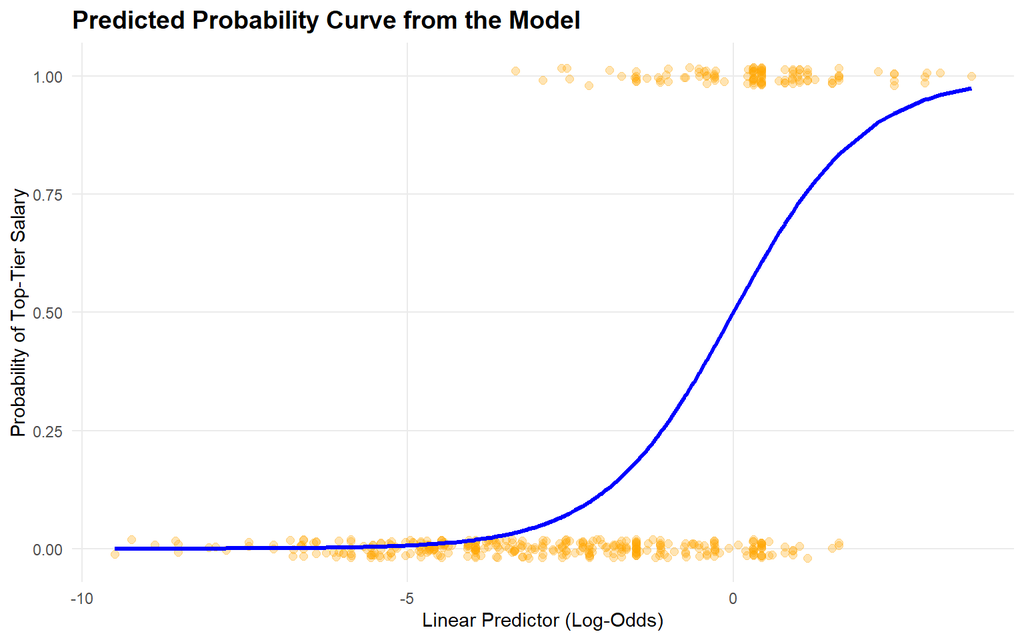

```r
# 1. Extract the linear predictors (log-odds) and fitted probabilities
plot_data <- train %>%
  mutate(
    predicted_prob = predict(logit_model, type = "response"),
    log_odds = predict(logit_model, type = "link")
  )

# 2. Plot the logistic curve and the actual observations
ggplot(plot_data, aes(x = log_odds)) +

  # Scatter plot of actual observations (Y = 0 or 1)
  # Jitter is added to the y-axis to match the visual style of the reference plot
  geom_jitter(
    aes(y = is_top_tier),
    width = 0,
    height = 0.02,
    color = "orange",
    alpha = 0.3,
    size = 2
  ) +

  # The S-curve representing the predicted probability
  geom_line(
    aes(y = predicted_prob),
    color = "blue",
    linewidth = 1.2
  ) +

  # Formatting the plot
  theme_minimal() +
  labs(
    title = "Predicted Probability Curve from the Model",
    x = "Linear Predictor (Log-Odds)",
    y = "Probability of Top-Tier Salary"
  ) +
  scale_y_continuous(breaks = seq(0, 1, by = 0.25)) +
  theme(
    panel.grid.minor = element_blank(),
    plot.title = element_text(size = 14, face = "bold")
  )
```

### 5.4.2 In-Sample Confusion Matrix and Classification Metrics

To evaluate classification performance on the training data, predicted probabilities are converted to binary classes using a 0.5 decision threshold. The confusion matrix below summarizes in-sample classification accuracy and breakdown of True Positives (TP), False Positives (FP), True Negatives (TN), and False Negatives (FN).

```r
# Generate in-sample predictions on training set
train_predictions <- train %>%
  mutate(
    predicted_probability = predict(logit_model, type = "response"),
    predicted_class = if_else(predicted_probability >= 0.5, 1L, 0L)
  )

# Compute confusion matrix
cm_train <- table(
  Actual = train_predictions$is_top_tier,
  Predicted = train_predictions$predicted_class
)

cat("=== In-Sample Confusion Matrix (Training Set, n=", nrow(train), ") ===\n", sep = "")
```

```
## === In-Sample Confusion Matrix (Training Set, n=452) ===
```

```r
print(cm_train)
```

```
##       Predicted
## Actual   0   1
##      0 296  40
##      1  39  77
```

```r
# Extract and display classification metrics
tn_train <- cm_train[1, 1]
fp_train <- cm_train[1, 2]
fn_train <- cm_train[2, 1]
tp_train <- cm_train[2, 2]

cat("\n=== Classification Breakdown ===\n")
```

```
##
## === Classification Breakdown ===
```

```r
cat("True Negatives (TN):    ", tn_train, " (actual=0, predicted=0)\n")
```

```
## True Negatives (TN):     296  (actual=0, predicted=0)
```

```r
cat("False Positives (FP):   ", fp_train, " (actual=0, predicted=1)\n")
```

```
## False Positives (FP):    40  (actual=0, predicted=1)
```

```r
cat("False Negatives (FN):   ", fn_train, " (actual=1, predicted=0)\n")
```

```
## False Negatives (FN):    39  (actual=1, predicted=0)
```

```r
cat("True Positives (TP):    ", tp_train, " (actual=1, predicted=1)\n")
```

```
## True Positives (TP):     77  (actual=1, predicted=1)
```

```r
# Calculate in-sample classification metrics
accuracy_train <- (tp_train + tn_train) / (tp_train + tn_train + fp_train + fn_train)
sensitivity_train <- tp_train / (tp_train + fn_train)
specificity_train <- tn_train / (tn_train + fp_train)
fpr_train <- fp_train / (tn_train + fp_train)
fnr_train <- fn_train / (tp_train + fn_train)

metrics_train <- tibble(
  Metric = c("Accuracy", "Sensitivity (True Positive Rate)", "Specificity (True Negative Rate)",
             "False Positive Rate", "False Negative Rate"),
  Value = c(accuracy_train, sensitivity_train, specificity_train, fpr_train, fnr_train),
  Interpretation = c(
    "Proportion of correct classifications",
    "Proportion of actual top-tier correctly identified",
    "Proportion of actual non-top-tier correctly identified",
    "Proportion of non-top-tier misclassified as top-tier",
    "Proportion of top-tier misclassified as non-top-tier"
  )
) %>%
  mutate(Value = round(Value, 4))

knitr::kable(
  metrics_train,
  caption = "In-sample classification metrics (training set)"
)
```

In-sample classification metrics (training set)

| Metric | Value | Interpretation |
| --- | --- | --- |
| Accuracy | 0.8252 | Proportion of correct classifications |
| Sensitivity (True Positive Rate) | 0.6638 | Proportion of actual top-tier correctly identified |
| Specificity (True Negative Rate) | 0.8810 | Proportion of actual non-top-tier correctly identified |
| False Positive Rate | 0.1190 | Proportion of non-top-tier misclassified as top-tier |
| False Negative Rate | 0.3362 | Proportion of top-tier misclassified as non-top-tier |

The training set confusion matrix and metrics provide a baseline for in-sample performance. The 0.5 probability threshold classifies observations based on the model’s fitted probabilities; this threshold can be adjusted in Task 6 to optimize for specific business objectives (e.g., minimizing false positives).

## 5.5 Out-of-Sample Predictions for Task 6 Evaluation

The fitted logistic model is applied to the supplied test set below to generate predictions for evaluation in Task 6. Classification metrics (accuracy, sensitivity, specificity, ROC-AUC, precision, F1-score) will be computed from the test-set predictions to assess the model’s generalization capability.

```r
test_predictions <- test %>%
  mutate(
    predicted_probability = predict(logit_model, newdata = test, type = "response"),
    predicted_class = if_else(predicted_probability >= 0.5, 1L, 0L)
  )

head(test_predictions[c("row_id", "is_top_tier", "predicted_probability", "predicted_class")])
```

|  | row_id | is_top_tier | predicted_probability | predicted_class |
| --- | --- | --- | --- | --- |
| 1 | 5 | 1 | 0.728694717 | 1 |
| 2 | 16 | 0 | 0.001658915 | 0 |
| 3 | 21 | 0 | 0.026811637 | 0 |
| 4 | 32 | 0 | 0.147833390 | 0 |
| 5 | 37 | 0 | 0.551603257 | 1 |
| 6 | 49 | 0 | 0.397443144 | 0 |

## 5.6 Interpretation and Main Findings

### 5.6.1 Training Set Findings

The odds-ratio table is estimated from the supplied training observations. Each odds ratio compares one category with its reference category while holding the other predictors constant. The reference profile is entry-level (EN), small-company (S), 0% remote work, Data Analyst, full-time employment, and a non-US company location. For example, an odds ratio above 1 for US company location means that the estimated odds of being top-tier are higher than those for a comparable non-US company, not that salary itself multiplies by this factor.

Interpret the printed table using these comparison groups. In this fitted model, the statistically significant positive associations on the training data include senior and executive experience, large company size, several technical or management job categories, and US company location. Estimates for small sub-groups should be treated cautiously because their wider confidence intervals show greater instability.

These are adjusted associations observed in the training data, not causal salary effects. The model contains no interaction terms, so each coefficient describes an average association under the model’s additive assumption. A non-significant coefficient on the training set does not prove that a characteristic has no effect; it simply indicates a lack of statistically significant evidence at the 5% level in the training sample. Estimates for the non-full-time and 50% remote-work groups should be treated cautiously because their smaller sample sizes produce wider confidence intervals in the training data.

### 5.6.2 Train-Test Evaluation Framework

The AIC and McFadden pseudo-$R^2$ summarize in-sample fit on the supplied training data. To assess whether the model’s learned associations generalize, the fitted model is applied to the supplied test set.